# single_analyse

## Start

```python
#!/usr/bin/env python3
# -*- coding: utf-8 -*-

import matplotlib
import matplotlib.pyplot as plt
from mpl_toolkits.mplot3d import Axes3D
from mpl_toolkits import mplot3d
%matplotlib inline

import numpy as np
import pandas as pd
import skimage
from sklearn.cluster import KMeans
from sklearn import mixture
import cv2
import math
import random

# from IPython.core.interactiveshell import InteractiveShell
# InteractiveShell.ast_node_interactivity = "all"
```

### Load data

```python
tgt_layer = 'convolution_7'
units = [0, 16, 26, 33, 37, 38, 47]
u_num = len(units)
unit_use = -1

data_all = np.zeros((u_num, 128, 128, 3))
data_black = np.zeros((128, 128, 3))
for i in range(u_num):
    data_all[i] = pd.read_pickle("./visualize_laplacian/visualize-lap-{}-{}-15.pkl".format(tgt_layer, units[i]))[64:192, 64:192]

data_row = data_all[unit_use]
```

### Glance of initial data

See what the data look like in its Red layer

```python
data_row[:, :, 0]
```

```
array([[0.49330398, 0.49352407, 0.49438893, ..., 0.49383453, 0.4930431 ,
        0.49395597],
       [0.49389733, 0.49318346, 0.49368159, ..., 0.49339894, 0.49408667,
        0.49276175],
       [0.49436606, 0.49409511, 0.49242701, ..., 0.49456925, 0.49431542,
        0.49407427],
       ...,
       [0.49373945, 0.49425464, 0.49245834, ..., 0.4944095 , 0.49422021,
        0.49369225],
       [0.49443032, 0.49239572, 0.4924258 , ..., 0.49428158, 0.49350076,
        0.49367562],
       [0.49288652, 0.49388603, 0.49244815, ..., 0.49412677, 0.4934252 ,
        0.49330082]])
```

Show the initial RGB data

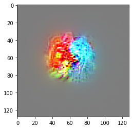

```python
data_RGB = np.uint8(np.clip(data_row, 0, 1) * 255.0)
plt.imshow(data_RGB)
```

Distribution in RGB space

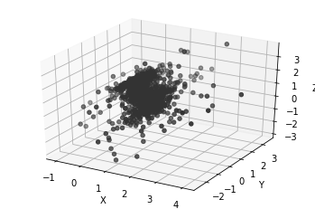

```python
ax = plt.axes(projection='3d')
ax.scatter(data_row[:, :, 0], data_row[:, :, 1], data_row[:, :, 2], c='#333333')

ax.set_zlabel('Z')
ax.set_ylabel('Y')
ax.set_xlabel('X')
plt.show()
```

Distribution in L*a*b space

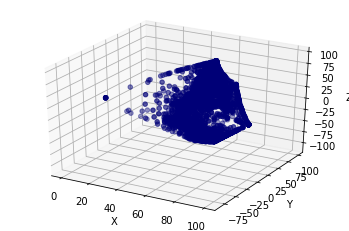

```python
data_Lab = skimage.color.rgb2lab(data_RGB)
ax = plt.axes(projection='3d')
ax.scatter(data_Lab[:, :, 0], data_Lab[:, :, 1], data_Lab[:, :, 2], c='#000077')

ax.set_zlabel('Z')
ax.set_ylabel('Y')
ax.set_xlabel('X')
plt.show()
```

## Preprocessing

### GMM

Turn the data from 3D to 2D: 128*128*3 -> 16384*3

Use GMM(Gaussian Mixture Model) method to clustering. It performs extremely good when dealing with concentric-circles-like data.

```python
image_array = data_row.reshape((data_row.shape[0] * data_row.shape[1], 3))

clst = mixture.GaussianMixture(n_components=3, max_iter=100, covariance_type="full")
clst.fit(image_array)
predicted_labels = clst.predict(image_array)
centroids_GMM = clst.means_
labels = predicted_labels
label_matrix = labels.reshape((128, 128))
```

RGB centroids of three classes divided by GMM.

```python
centroids_GMM
```

```
array([[0.49385604, 0.49410484, 0.49388607],
       [0.50594904, 0.50464256, 0.50160429],
       [0.67619376, 0.60117121, 0.56320992]])
```

Visualization of three classes divided by GMM.

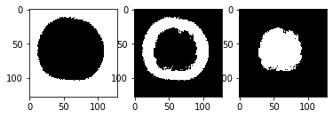

```python
data_gmm_0 = data_row.copy()
for i in range(128):
    for j in range(128):
        if label_matrix[i, j] == 0:
            data_gmm_0[i][j] = [1, 1, 1]
        else:
            data_gmm_0[i][j] = [0, 0, 0]
data_0 = np.uint8(np.clip(data_gmm_0, 0, 1) * 255.0)
plt.subplot(1, 3, 1)
plt.imshow(data_0)

data_gmm_1 = data_row.copy()
for i in range(128):
    for j in range(128):
        if label_matrix[i, j] == 1:
            data_gmm_1[i][j] = [1, 1, 1]
        else:
            data_gmm_1[i][j] = [0, 0, 0]
data_1 = np.uint8(np.clip(data_gmm_1, 0, 1) * 255.0)
plt.subplot(1, 3, 2)
plt.imshow(data_1)

data_gmm_2 = data_row.copy()
for i in range(128):
    for j in range(128):
        if label_matrix[i, j] == 2:
            data_gmm_2[i][j] = [1, 1, 1]
        else:
            data_gmm_2[i][j] = [0, 0, 0]
data_2 = np.uint8(np.clip(data_gmm_2, 0, 1) * 255.0)
plt.subplot(1, 3, 3)
plt.imshow(data_2)
```

To identify the index of class which represents the central colorful area. We can simply use the formula below to get the maximal index, since the other two classes are very close to zero, this method is super accurate.

$$ argmax_{0,1,2}(\Sigma_{i=0}^2|a_i-0.5|) $$

```python
baseline = np.array([0.5] * 9).reshape(3, 3)
max_index = np.argmax(np.sum(abs(centroids_GMM - baseline), axis=1))
```

Change the RGB values of the area other than the center area(the class has maximal index) in the original image to 0.5.

```python
data_center = data_row.copy()
for judge_index in range(3):
    if max_index == judge_index:
        for i in range(128):
            for j in range(128):
                if label_matrix[i, j] != judge_index:
                    data_center[i][j] = [0.5, 0.5, 0.5]
        break
```

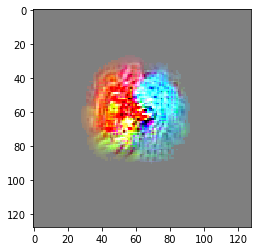

```python
data_center = np.clip(data_center, 0, 1)
plt.imshow(data_center)
```

Although it looks similar to the original image, the noise has been removed, which is very helpful for the subsequent processing.

### k-means

Turn the image data from 3D to 2D again to do the k-means clustering.

```python
image_array_new = data_center.reshape((data_row.shape[0] * data_row.shape[1], 3))

kmeans = KMeans(n_clusters=3,  init='k-means++')
kmeans.fit(image_array_new)
centroids_kmeans = kmeans.cluster_centers_
labels = kmeans.labels_
label_matrix_new = labels.reshape((128, 128))
```

RGB centroids of three classes divided by k-means.

```python
centroids_kmeans
```

```
array([[0.50218009, 0.50395222, 0.50124092],
       [0.45295649, 0.82902194, 0.89985118],
       [0.91931781, 0.39784717, 0.24122736]])
```

Visualization of three classes divided by k-means.

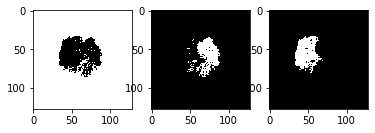

```python
data_0_new = data_center.copy()
for i in range(128):
    for j in range(128):
        if label_matrix_new[i, j] == 0:
            data_0_new[i][j] = [1, 1, 1]
        else:
            data_0_new[i][j] = [0, 0, 0]
plt.subplot(1, 3, 1)
plt.imshow(data_0_new)

data_1_new = data_center.copy()
for i in range(128):
    for j in range(128):
        if label_matrix_new[i, j] == 1:
            data_1_new[i][j] = [1, 1, 1]
        else:
            data_1_new[i][j] = [0, 0, 0]
plt.subplot(1, 3, 2)
plt.imshow(data_1_new)

data_2_new = data_center.copy()
for i in range(128):
    for j in range(128):
        if label_matrix_new[i, j] == 2:
            data_2_new[i][j] = [1, 1, 1]
        else:
            data_2_new[i][j] = [0, 0, 0]
plt.subplot(1, 3, 3)
plt.imshow(data_2_new)
```

I used k-means to divide data into three categories, one of which is the class of gray pixels representing the background. After removing it, the remaining two categories are what we need.

It is obvious that the background class must have the minimal value in the formula below.

$$ \Sigma_{i=0}^2|a_i-0.5| $$

```python
min_index = np.argmin(np.sum(abs(centroids_kmeans - baseline), axis=1))

if min_index == 0:
    data_A = data_1_new
    data_B = data_2_new
    class_A = 1
    class_B = 2
    avg_A = centroids_kmeans[1]
    avg_B = centroids_kmeans[2]
elif min_index == 1:
    data_A = data_0_new
    data_B = data_2_new
    class_A = 0
    class_B = 2
    avg_A = centroids_kmeans[0]
    avg_B = centroids_kmeans[2]
else:
    data_A = data_0_new
    data_B = data_1_new
    class_A = 0
    class_B = 1
    avg_A = centroids_kmeans[0]
    avg_B = centroids_kmeans[1]
```

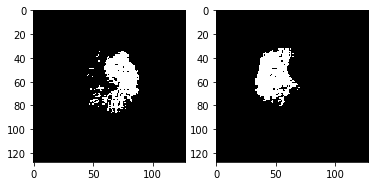

```python
plt.subplot(1, 2, 1)
plt.imshow(data_A)
plt.subplot(1, 2, 2)
plt.imshow(data_B)
```

### Dilation & Erosion

By dilation and erosion, we can remove discrete points and make the image form a connected domain as much as possible.

This operation is only used for ellipse fitting since it improves the ellipse fitting performance a lot, and the distortion of some data does not affect the correctness of the ellipse fitting result too much. However, in Gaussian fitting, we need to ensure the integrity of the data to get the right results.

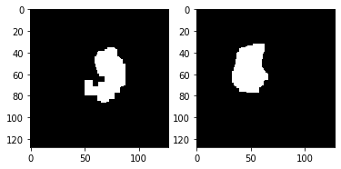

```python
kernel = np.ones((5, 5), np.uint8)
data_A = cv2.morphologyEx(cv2.morphologyEx(data_A, cv2.MORPH_CLOSE, kernel), cv2.MORPH_OPEN, kernel)
plt.subplot(1, 2, 1)
plt.imshow(data_A)

data_B = cv2.morphologyEx(cv2.morphologyEx(data_B, cv2.MORPH_CLOSE, kernel), cv2.MORPH_OPEN, kernel)
plt.subplot(1, 2, 2)
plt.imshow(data_B)
```

## Ellipse fitting

### Implementation

Find an external ellipse with OpenCV.

Some images will have multiple small ellipses after the erosion operation, the one has the longest parameter length(means the largest ellipse) should be taken.

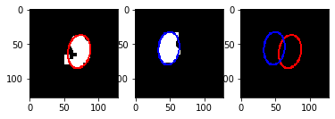

```python
x0_A, y0_A, a_A, b_A, angle_A, x0_B, y0_B, a_B, b_B, angle_B = (0 for _ in range(10))
img_merge = 0
max_cnt = 0
imgray = cv2.cvtColor(np.uint8(np.clip(data_A, 0, 1) * 255), cv2.COLOR_BGR2GRAY)
ret, thresh = cv2.threshold(imgray, 127, 255, 0)
_, contours, _ = cv2.findContours(thresh, cv2.RETR_TREE, cv2.CHAIN_APPROX_SIMPLE)
for cnt_index, cnt in enumerate(contours):
    # print("cnt_index, len(cnt): ", cnt_index, "\t", len(cnt))
    if len(cnt) > max_cnt:
        max_cnt = len(cnt)
        max_cnt_index = cnt_index
if max_cnt > 5:
    ellipse = cv2.fitEllipse(contours[max_cnt_index])
    x0_A, y0_A, a_A, b_A, angle_A = ellipse[0][0], ellipse[0][1], ellipse[1][0], ellipse[1][1], ellipse[2]
    img_tmp = cv2.ellipse(data_A, ellipse, (1, 0, 0), 2)
    img_merge = cv2.ellipse(data_black, ellipse, (1, 0, 0), 2)
    plt.subplot(1, 3, 1)
    plt.imshow(img_tmp)

max_cnt = 0
imgray = cv2.cvtColor(np.uint8(np.clip(data_B, 0, 1) * 255), cv2.COLOR_BGR2GRAY)
ret, thresh = cv2.threshold(imgray, 127, 255, 0)
_, contours, _ = cv2.findContours(thresh, cv2.RETR_TREE, cv2.CHAIN_APPROX_SIMPLE)
for cnt_index, cnt in enumerate(contours):
    if len(cnt) > max_cnt:
        max_cnt = len(cnt)
        max_cnt_index = cnt_index
if max_cnt > 5:
    ellipse = cv2.fitEllipse(contours[max_cnt_index])
    x0_B, y0_B, a_B, b_B, angle_B = ellipse[0][0], ellipse[0][1], ellipse[1][0], ellipse[1][1], ellipse[2]
    img_tmp = cv2.ellipse(data_B, ellipse, (0, 0, 1), 2)
    img_merge = cv2.ellipse(img_merge, ellipse, (0, 0, 1), 2)
    plt.subplot(1, 3, 2)
    plt.imshow(img_tmp)
    plt.subplot(1, 3, 3)
    plt.imshow(img_merge)
```

Compare to the initial image.

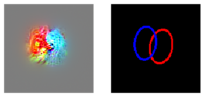

```python
    plt.subplot(1, 2, 1)
    plt.axis('off')
    plt.imshow(data_RGB)
    plt.subplot(1, 2, 2)
    plt.axis('off')
    plt.imshow(img_merge)
```

### Result

$Category\_1:x_0,y_0,a,b,\theta=$

```python
x0_A, y0_A, a_A, b_A, angle_A
```

```
(71.176513671875,
 61.02641296386719,
 31.86046600341797,
 48.6713981628418,
 10.41258716583252)
```

$Category\_2:x_0,y_0,a,b,\theta=$

```python
x0_B, y0_B, a_B, b_B, angle_B
```

```
(48.62747573852539,
 56.208160400390625,
 30.422733306884766,
 47.428565979003906,
 6.324682235717773)
```

## Gaussian fitting(xy-axes)

### Theory

The model of the two-dimensional Gaussian function is expressed as:

$$ f(x,y)=Aexp(-\frac{(x-x_0)^2}{2\sigma_x^2}-\frac{(y-y_0)^2}{2\sigma_y^2}) $$

In order to facilitate the calculation, take the logarithm on both sides and get:

$$ lnf=lnA-\frac{(x-x_0)^2}{2\sigma_x^2}-\frac{(y-y_0)^2}{2\sigma_y^2} $$

Expand and further transform into: $$ lnf=ax^2+by^2+cx+dy+e $$

$$ \begin{Bmatrix} a=-\frac{1}{2\sigma_x^2} \\ b=-\frac{1}{2\sigma_y^2} \\ c=\frac{x_0}{\sigma_x^2} \\ d=\frac{y_0}{\sigma_y^2} \\ e= lnA-\frac{x_0}{2\sigma_x^2}-\frac{y_0}{2\sigma_y^2} \end{Bmatrix} $$

Then it becomes a binary quadratic polynomial fitting problem.

Least squares solution to minimize the sum of squared residuals:

$$ Q=min\Sigma(ax^2+by^2+cx+dy+e-lny)^2 $$

Find the partial derivative for each variable and make it zero, and get the equations:

$$ \begin{Bmatrix} 2\Sigma(ax^2+by^2+cx+dy+e-lnf)\Sigma x^2=0 \\ 2\Sigma(ax^2+by^2+cx+dy+e-lnf)\Sigma y^2=0 \\ 2\Sigma(ax^2+by^2+cx+dy+e-lnf)\Sigma x=0 \\ 2\Sigma(ax^2+by^2+cx+dy+e-lnf)\Sigma y=0 \\ 2\Sigma(ax^2+by^2+cx+dy+e-lnf)\Sigma 1=0 \end{Bmatrix} $$

Further transformation:

$$ \begin{Bmatrix} \Sigma(ax^4+by^2x^2+cx^3+dx^2y+ex^2)=\Sigma x^2lnf \\ \Sigma(ax^2y^2+by^4+cxy^2+dy^3+ey^2)=\Sigma y^2lnf \\ \Sigma(ax^3+bxy^2+cx^2+dxy+ex)=\Sigma xlnf \\ \Sigma(ax^2y+by^3+cxy+dy^2+ey)=\Sigma ylnf \\ \Sigma(ax^2+by^2+cx+dy+e)=\Sigma lnf \end{Bmatrix} $$

Get the linear equations:

$$ BK=C $$

in which,

$$ B =\begin{bmatrix} \Sigma x^4 & \Sigma x^2y^2 & \Sigma x^3 & \Sigma x^2y & \Sigma x^2 \\ \Sigma x^2y^2 & \Sigma y^4 & \Sigma xy^2 & \Sigma y^3 & \Sigma y^2 \\ \Sigma x^3 & \Sigma xy^2 & \Sigma x^2 & \Sigma xy & \Sigma x \\ \Sigma x^2y & \Sigma y^3 & \Sigma xy & \Sigma y^2 & \Sigma y \\ \Sigma x^2 & \Sigma y^2 & \Sigma x & \Sigma y & \Sigma 1 \end{bmatrix} $$$$ K=\begin{bmatrix} a \\ b \\ c \\ d \\ e \end{bmatrix} $$$$ C=\begin{bmatrix} \Sigma x^2lnf \\ \Sigma y^2lnf \\ \Sigma xlnf \\ \Sigma ylnf \\ \Sigma lnf \end{bmatrix} $$

Solving this linear equations to get the parameters of Gaussian function:

$$ K=B^{-1}C $$

### Implementation

```python
def Gaussian_fit(x, y, value):
    C = np.array([np.sum(x ** 2 * np.log(value)),
                  np.sum(y ** 2 * np.log(value)),
                  np.sum(x * np.log(value)),
                  np.sum(y * np.log(value)),
                  np.sum(np.log(value))])

    B = np.array([[np.sum(x ** 4), np.sum(x ** 2 * y ** 2), np.sum(x ** 3), np.sum(x ** 2 * y), np.sum(x ** 2)],
                  [np.sum(x ** 2 * y ** 2), np.sum(y ** 4), np.sum(x * y ** 2), np.sum(y ** 3), np.sum(y ** 2)],
                  [np.sum(x ** 3), np.sum(x * y ** 2), np.sum(x ** 2), np.sum(x * y), np.sum(x)],
                  [np.sum(x ** 2 * y), np.sum(y ** 3), np.sum(x * y), np.sum(y ** 2), np.sum(y)],
                  [np.sum(x ** 2), np.sum(y ** 2), np.sum(x), np.sum(y), len(value)]])

    B_inv = np.linalg.inv(B)
    K = B_inv.dot(C.T)
    return K
```

Perform Gaussian fitting after converting the 3D RGB values into one-dimensional gray values.

$$ Gray = R*0.2989 + G*0.5870 + B*0.1140 $$

```python
x_A, y_A, value_A, x_B, y_B, value_B = ([] for _ in range(6))

for i in range(128):
    for j in range(128):
        if np.sum(data_center[i, j]) != 0:
            if label_matrix_new[i, j] == class_A:
                x_A.append(i)
                y_A.append(j)
                value_A.append((data_center[i][j][0] * 0.2989 + data_center[i][j][1] * 0.5870 + data_center[i][j][2] * 0.1140))
            else:
                x_A.append(i)
                y_A.append(j)
                value_A.append(0.01)
            if label_matrix_new[i, j] == class_B:
                x_B.append(i)
                y_B.append(j)
                value_B.append((data_center[i][j][0] * 0.2989 + data_center[i][j][1] * 0.5870 + data_center[i][j][2] * 0.1140))
            else:
                x_B.append(i)
                y_B.append(j)
                value_B.append(0.01)

K_A = Gaussian_fit(np.array(x_A), np.array(y_A), np.array(value_A))
K_B = Gaussian_fit(np.array(x_B), np.array(y_B), np.array(value_B))
```

### Result

$Category\_1:x_0,y_0=$

```python
K_A[2] / (-2 * K_A[0]), K_A[3] / (-2 * K_A[1])
```

```
(61.48090684093207, 67.17638708135141)
```

$Category\_2:x_0,y_0=$

```python
K_B[2] / (-2 * K_B[0]), K_B[3] / (-2 * K_B[1])
```

```
(59.59969067177072, 55.67564254057699)
```

$Category\_1:\sigma_x ^2,\sigma_y ^2=$

```python
1 / (-2 * K_A[0]), 1 / (-2 * K_A[1])
```

```
(2526.618132866652, 2456.5515236971564)
```

$Category\_2:\sigma_x ^2,\sigma_y ^2=$

```python
1 / (-2 * K_B[0]), 1 / (-2 * K_B[1])
```

```
(2618.3190324817074, 2849.5505999987245)
```

$Category\_1:A=$

```python
np.exp((-1 * K_A[2] ** 2) / (4 * K_A[0]) + (-1 * K_A[3] ** 2) / (4 * K_A[1]) + K_A[4])
```

```
0.022257906986609854
```

$Category\_2:A=$

```python
np.exp((-1 * K_B[2] ** 2) / (4 * K_B[0]) + (-1 * K_B[3] ** 2) / (4 * K_B[1]) + K_B[4])
```

```
0.021364072939734708
```

### 3D display

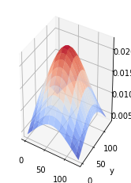

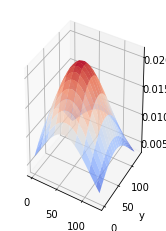

```python
x, y = np.mgrid[0:128:20j, 0:128:20j]

z = np.exp(K_A[0] * (x ** 2) + K_A[1] * (y ** 2) + K_A[2] * x + K_A[3] * y + K_A[4])
ax = plt.subplot(121, projection='3d')
ax.plot_surface(x, y, z, rstride=2, cstride=1, cmap=plt.cm.coolwarm, alpha=0.8)
ax.set_xlabel('x')
ax.set_ylabel('y')
ax.set_zlabel('z')
plt.show()

z = np.exp(K_B[0] * (x ** 2) + K_B[1] * (y ** 2) + K_B[2] * x + K_B[3] * y + K_B[4])
ax = plt.subplot(122, projection='3d')
ax.plot_surface(x, y, z, rstride=2, cstride=1, cmap=plt.cm.coolwarm, alpha=0.8)
ax.set_xlabel('x')
ax.set_ylabel('y')
ax.set_zlabel('z')
plt.show()
```

## Gaussian fitting(rotation)

### Theory

$$ f(x,y)=Aexp(-\frac{(x-x_0)^2}{2\sigma_x^2}-\frac{(y-y_0)^2}{2\sigma_y^2}) $$$$ \begin{bmatrix}x' \\ y'\end{bmatrix}= \begin{bmatrix} cos\theta & -sin\theta \\ sin\theta & cos\theta \end{bmatrix}* \begin{bmatrix}x \\ y\end{bmatrix} $$$$ \theta\in(0,\frac{\pi}{2}) $$$$ argmin(\sigma_x^2+\sigma_y^2) $$

### Implementation

```python
def Gaussian_fit_rotation(x, y, value):
    best_score = 999999999
    best_angle = None
    for i in range(0, 100):
        # Generate random angle values from 0 to 90
        angle = random.uniform(0, 90)
        radian = angle * np.pi / 180

        x_new = np.array(x) * np.cos(radian) - np.array(y) * np.sin(radian)
        y_new = np.array(x) * np.sin(radian) + np.array(y) * np.cos(radian)
        M = Gaussian_fit(x_new, y_new, np.array(value))

        # find the least cost
        current_score = 1 / (-2 * M[0]) + 1 / (-2 * M[1])
        # cost = costf(x_A, y_A, value_A, angle * np.pi / 180)

        if current_score < best_score:
            best_score = current_score
            best_angle = angle
            K = M

    K = np.append(K, best_angle)
    return K
```

```python
K_A_rotation = Gaussian_fit_rotation(np.array(x_A), np.array(y_A), np.array(value_A))
K_B_rotation = Gaussian_fit_rotation(np.array(x_B), np.array(y_B), np.array(value_B))
```

### Result

$Category\_1:x_0,y_0=$

```python
K_A_rotation[2] / (-2 * K_A_rotation[0]), K_A_rotation[3] / (-2 * K_A_rotation[1])
```

```
(-56.576279999241166, 71.42806629432089)
```

$Category\_2:x_0,y_0=$

```python
K_B_rotation[2] / (-2 * K_B_rotation[0]), K_B_rotation[3] / (-2 * K_B_rotation[1])
```

```
(-44.009739040317655, 68.7933939795574)
```

$Category\_1:\sigma_x ^2,\sigma_y ^2=$

```python
1 / (-2 * K_A_rotation[0]), 1 / (-2 * K_A_rotation[1])
```

```
(2490.461536382805, 2491.7235968150762)
```

$Category\_2:\sigma_x ^2,\sigma_y ^2=$

```python
1 / (-2 * K_B_rotation[0]), 1 / (-2 * K_B_rotation[1])
```

```
(2731.9491137864884, 2726.1469942714584)
```

$Category\_1:A=$

```python
np.exp((-1 * K_A_rotation[2] ** 2) / (4 * K_A_rotation[0]) + (-1 * K_A_rotation[3] ** 2) / (4 * K_A_rotation[1]) + K_A_rotation[4])
```

```
0.022258498331179943
```

$Category\_2:A=$

```python
np.exp((-1 * K_B_rotation[2] ** 2) / (4 * K_B_rotation[0]) + (-1 * K_B_rotation[3] ** 2) / (4 * K_B_rotation[1]) + K_B_rotation[4])
```

```
0.021357058059082255
```

$Category\_1:\theta=$

```python
K_A_rotation[5]
```

```
80.8386498160202
```

$Category\_2:\theta=$

```python
K_B_rotation[5]
```

```
79.31589916159037
```

## Evaluation

### Color contrast ratio

Average RGB of category 1 and 2:

```python
avg_A
```

```
array([0.45295649, 0.82902194, 0.89985118])
```

```python
avg_B
```

```
array([0.91931781, 0.39784717, 0.24122736])
```

```python
def luminanace(r, g, b):
    a = np.array(list(map(lambda x: x / 12.92 if x <= 0.03928 else pow((x + 0.055) / 1.055, 2.4), [r, g, b])))
    c = np.array([0.2126, 0.7152, 0.0722])
    return np.sum(a * c)


def contrast(rgb1, rgb2):
    return (luminanace(rgb1[0], rgb1[1], rgb1[2]) + 0.05) / (luminanace(rgb2[0], rgb2[1], rgb2[2]) + 0.05)
```

Color Contrast Ration(details are [here](https://webaim.org/resources/contrastchecker/))

```python
max(contrast(avg_A, avg_B), contrast(avg_B, avg_A))
```

```
1.8930518777311658
```